# Практическая работа Анализ данных в среде RStudio

Шутемов А.А., 6371

13 11 2020

## Задание №1. Загружаем датасет.

Данный датасет использовался в предыдущей практической работе и содержит данные о медицинских отгулах работников на предприятии.

```r
path = "C:\\Users\\HP\\Documents\\GitHub\\RLaboratoryWork\\Absenteeism_at_work.csv"

dt <- read.table(path, header = T, sep=";")
```

### Размерность датасета

```r
dim(dt)
```

```
## [1] 740  21
```

```r
names(dt)
```

```
##  [1] "ID"                              "Reason.for.absence"
##  [3] "Month.of.absence"                "Day.of.the.week"
##  [5] "Seasons"                         "Transportation.expense"
##  [7] "Distance.from.Residence.to.Work" "Service.time"
##  [9] "Age"                             "Work.load.Average.day"
## [11] "Hit.target"                      "Disciplinary.failure"
## [13] "Education"                       "Son"
## [15] "Social.drinker"                  "Social.smoker"
## [17] "Pet"                             "Weight"
## [19] "Height"                          "Body.mass.index"
## [21] "Absenteeism.time.in.hours"
```

### Отобразим таблицу частот классов

```r
tbl <- table(dt$Reason.for.absence)
tbl
```

```
##
##   0   1   2   3   4   5   6   7   8   9  10  11  12  13  14  15  16  17  18  19
##  43  16   1   1   2   3   8  15   6   4  25  26   8  55  19   2   3   1  21  40
##  21  22  23  24  25  26  27  28
##   6  38 149   3  31  33  69 112
```

## Задание №2. Выполним статистический анализ по показателям.

Приведем 5 статистик по показателям:

1. Причина отсутствия
2. Месяц в котором было зафиксировано отсутвие
3. Сезон
4. Индекс массы тела работника
5. Время отсутвия в часах

```r
summary(dt[,c("Reason.for.absence","Month.of.absence","Seasons","Body.mass.index","Absenteeism.time.in.hours")])
```

```
##  Reason.for.absence Month.of.absence    Seasons      Body.mass.index
##  Min.   : 0.00      Min.   : 0.000   Min.   :1.000   Min.   :19.00
##  1st Qu.:13.00      1st Qu.: 3.000   1st Qu.:2.000   1st Qu.:24.00
##  Median :23.00      Median : 6.000   Median :3.000   Median :25.00
##  Mean   :19.22      Mean   : 6.324   Mean   :2.545   Mean   :26.68
##  3rd Qu.:26.00      3rd Qu.: 9.000   3rd Qu.:4.000   3rd Qu.:31.00
##  Max.   :28.00      Max.   :12.000   Max.   :4.000   Max.   :38.00
##  Absenteeism.time.in.hours
##  Min.   :  0.000
##  1st Qu.:  2.000
##  Median :  3.000
##  Mean   :  6.924
##  3rd Qu.:  8.000
##  Max.   :120.000
```

Отрисуем графики зависимостей:

1. Предположим, что причина отсутвия по медицинским причинам связана с индексом массы тела работника:

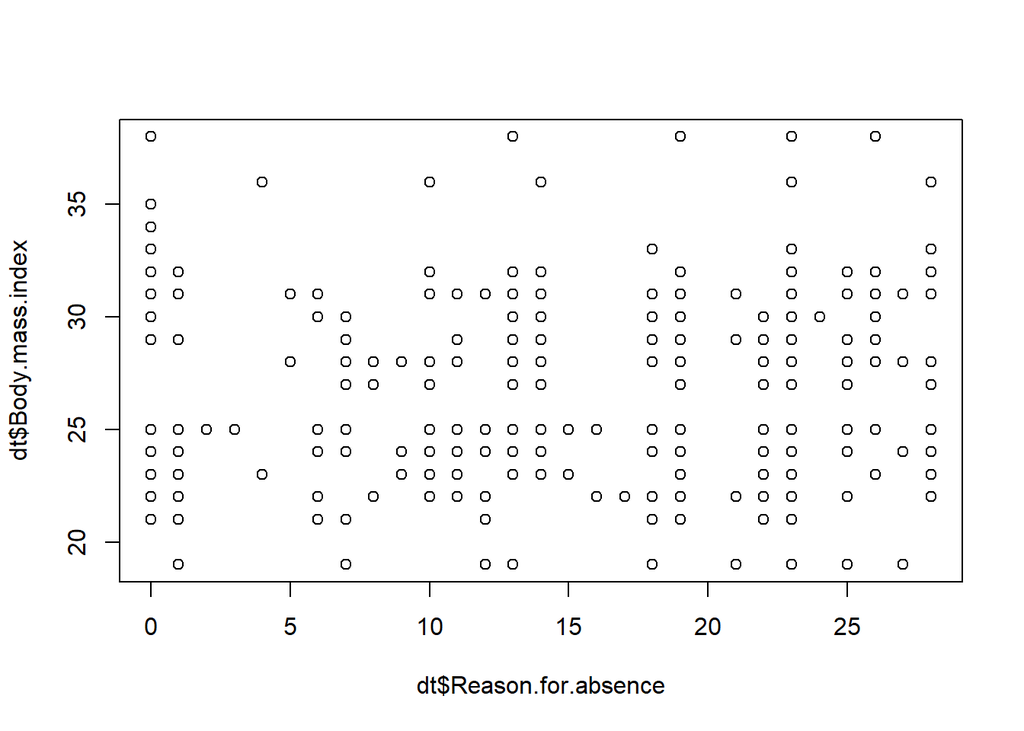

Но, как видно, объекты распределены довольно равномерно.

2. Возьмем другую пару, индекс массы тела и рост работника:

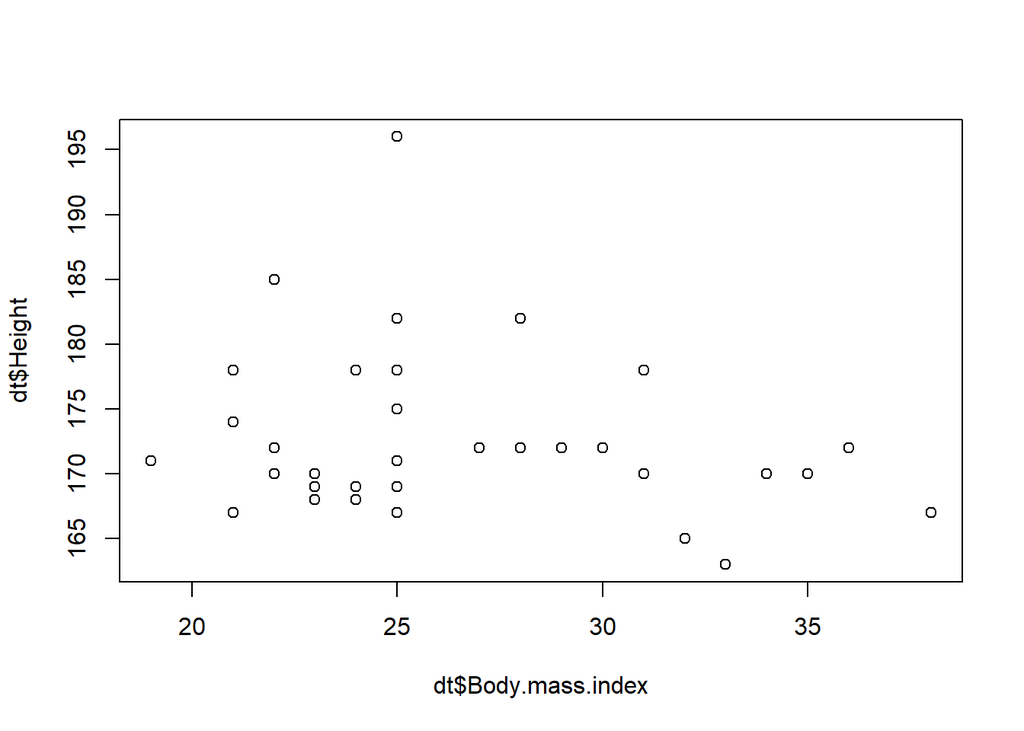

Здесь уже виднеется некоторая корреляция данных.

3. Также построим график зависимости причины отсутствия и месяца:

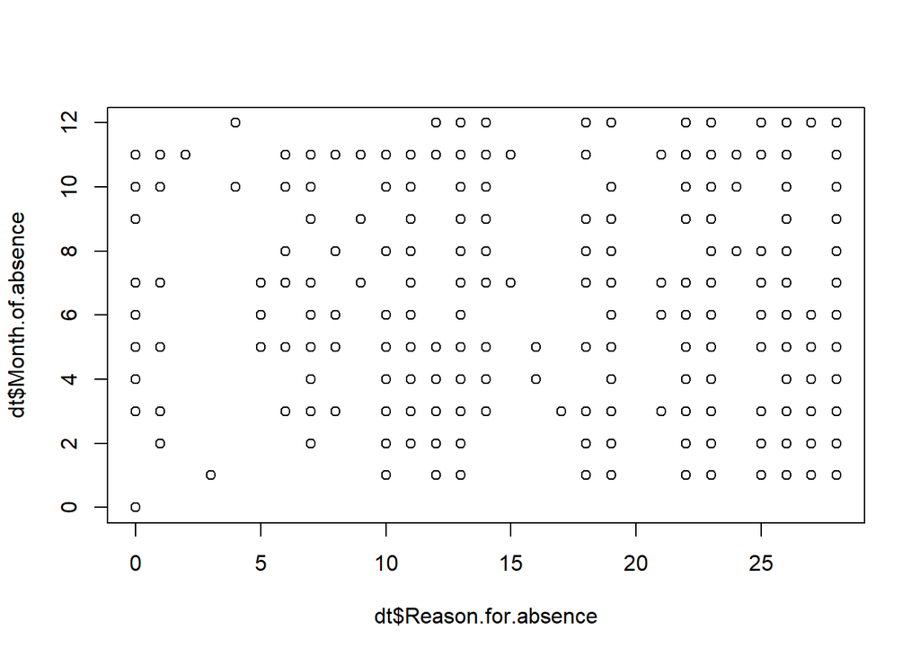

Распределение объектов, так же как и в первом пункте, выглядит равномемерным.

## Задание №3. Выполним статистический анализ зависимости класса от отдельных показателей.

Для этого исследуем зависимость причин отгула работника от его социального статуса “курильщик”:

1. Т.к. эти показатели являются качественными, построим таблицу сопряженности

```r
table <- table(dt$Reason.for.absence, dt$Social.smoker)

table
```

```
##
##        0   1
##   0   35   8
##   1   15   1
##   2    1   0
##   3    1   0
##   4    2   0
##   5    3   0
##   6    8   0
##   7   13   2
##   8    4   2
##   9    4   0
##   10  24   1
##   11  23   3
##   12   8   0
##   13  54   1
##   14  16   3
##   15   1   1
##   16   1   2
##   17   0   1
##   18  17   4
##   19  36   4
##   21   4   2
##   22  34   4
##   23 145   4
##   24   3   0
##   25  24   7
##   26  33   0
##   27  69   0
##   28 108   4
```

```r
fisher.test(table,simulate.p.value=TRUE,B=1e3)
```

```
##
##  Fisher's Exact Test for Count Data with simulated p-value (based on
##  1000 replicates)
##
## data:  table
## p-value = 0.000999
## alternative hypothesis: two.sided
```

Отрисуем barplot этой зависимости:

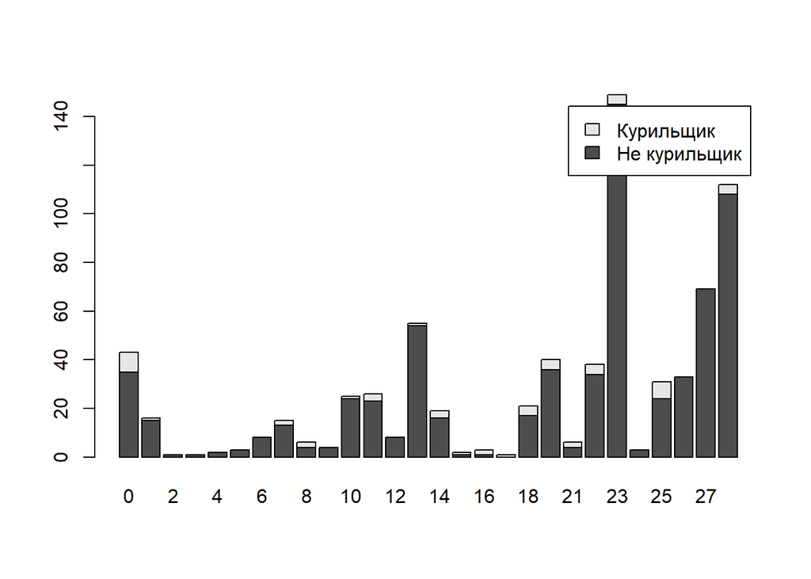

```r
# Class ~ f1
tableClassOfF1 = table(dt$Social.smoker,dt$Reason.for.absence)
barplot(tableClassOfF1, legend.text = c("Не курильщик", "Курильщик"))
```

Приведем результаты анализа различий для выбранных показателей

```r
table <- table(dt$Social.smoker,dt$Reason.for.absence)
wilcox.test(dt$Social.smoker,dt$Reason.for.absence)
```

```
##
##  Wilcoxon rank sum test with continuity correction
##
## data:  dt$Social.smoker and dt$Reason.for.absence
## W = 17503, p-value < 2.2e-16
## alternative hypothesis: true location shift is not equal to 0
```

Т.к. значение p-value значительно меньше 0.05, то делаем вывод, что на предоставленном датасете выбранные показатели зависимы.

2. Попробуем выяснить зависимость класса (Причина отгула) от непрерывного показателя Weight (Вес)

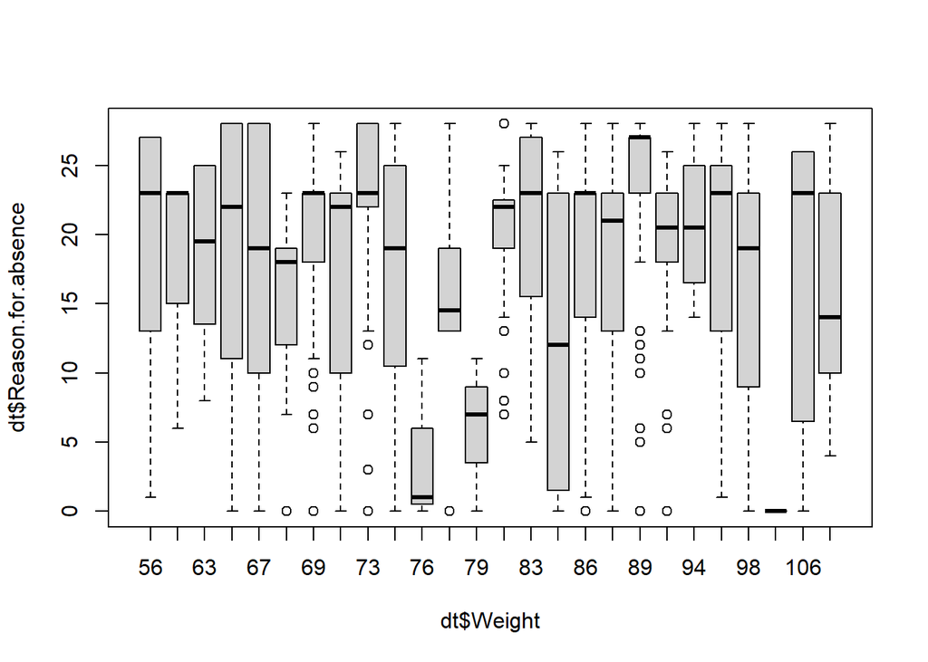

```r
table <- table(dt$Reason.for.absence)
boxplot(dt$Reason.for.absence ~ dt$Weight, dt)
```

```r
wilcox.test(dt$Reason.for.absence, dt$Weight)
```

```
##
##  Wilcoxon rank sum test with continuity correction
##
## data:  dt$Reason.for.absence and dt$Weight
## W = 0, p-value < 2.2e-16
## alternative hypothesis: true location shift is not equal to 0
```

Т.к. значение p-value значительно меньше 0.05, то так же делаем вывод, что на предоставленном датасете выбранные показатели зависимы.

## Задание №4.

### Подготовим данные

Исключим показатель ID (номер работника)

```r
dt["ID"]<-NULL

names(dt)
```

```
##  [1] "Reason.for.absence"              "Month.of.absence"
##  [3] "Day.of.the.week"                 "Seasons"
##  [5] "Transportation.expense"          "Distance.from.Residence.to.Work"
##  [7] "Service.time"                    "Age"
##  [9] "Work.load.Average.day"           "Hit.target"
## [11] "Disciplinary.failure"            "Education"
## [13] "Son"                             "Social.drinker"
## [15] "Social.smoker"                   "Pet"
## [17] "Weight"                          "Height"
## [19] "Body.mass.index"                 "Absenteeism.time.in.hours"
```

```r
indClass <- 1 #1 - причина отгула, 4 - сезон

names(dt)[indClass]
```

```
## [1] "Reason.for.absence"
```

**Проверим наличие пропусков**

```r
na <- apply(dt, 2, function(v) sum(is.na(v))) # v - vector
na
```

```
##              Reason.for.absence                Month.of.absence
##                               0                               0
##                 Day.of.the.week                         Seasons
##                               0                               0
##          Transportation.expense Distance.from.Residence.to.Work
##                               0                               0
##                    Service.time                             Age
##                               0                               0
##           Work.load.Average.day                      Hit.target
##                               0                               0
##            Disciplinary.failure                       Education
##                               0                               0
##                             Son                  Social.drinker
##                               0                               0
##                   Social.smoker                             Pet
##                               0                               0
##                          Weight                          Height
##                               0                               0
##                 Body.mass.index       Absenteeism.time.in.hours
##                               0                               0
```

**Пропусков нет**

**Затем разделим весь датасет на обучающую и тестовую выборку**

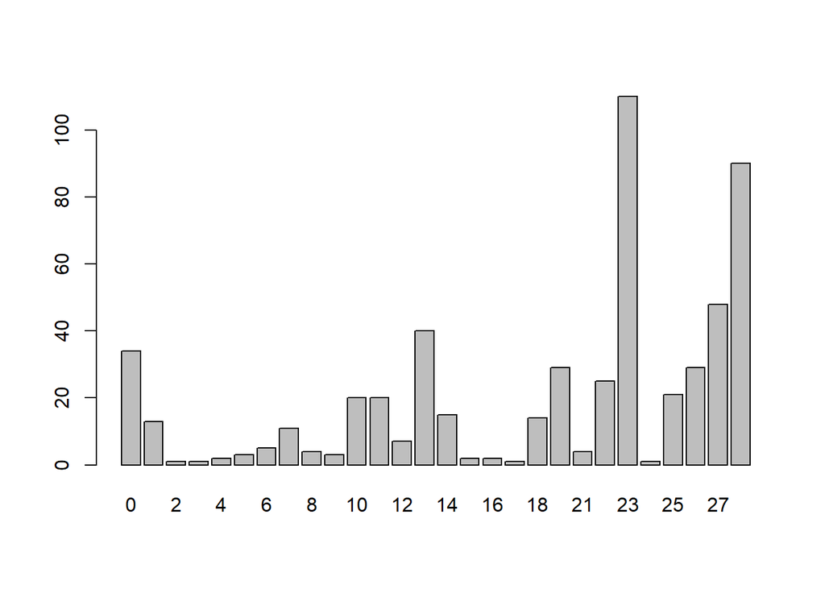

```r
train.size <- floor(nrow(dt) * .75) # отбираем 75 процентов имеющихся объектов

train.ind <- sample(seq_len(nrow(dt)), size = train.size)

dt.train <- dt[train.ind, ]
dt.test <- dt[-train.ind, ]

barplot(table(dt.train$Reason.for.absence))
```

### 4.1 Выполним классификацию данных.

### 1. С помощью метода knn

```r
library(class)
 # устраняем из таргет таблицы показатель класса, затем передаем обучающее множество с известным показателем класса и тестовое множество без показателя класса, необязательный параметр k=11 - кол. соседей
predicted <- knn(train = dt.train[, -indClass], cl = dt.train[, indClass], test = dt.test[-indClass], k=11)

# отобразим начало вектора
head(predicted)
```

```
## [1] 23 28 28 28 28 28
## 28 Levels: 0 1 2 3 4 5 6 7 8 9 10 11 12 13 14 15 16 17 18 19 21 22 23 24 ... 28
```

**Посчитаем точность классификации**

```r
#Выполним сопоставление тестовых и натренированных данных
sum(predicted == dt.test[, indClass])/ nrow(dt.test)
```

```
## [1] 0.2540541
```

**Построим матрицу ошибок**

```r
table = table(PREDICTED = predicted, REAL = dt.test[, indClass])

table
```

```
##          REAL
## PREDICTED  0  1  6  7  8  9 10 11 12 13 14 16 18 19 21 22 23 24 25 26 27 28
##        0   1  0  0  0  0  0  0  0  0  0  0  0  0  0  0  2  0  0  0  2  0  0
##        1   0  0  0  0  0  0  0  0  0  0  0  0  0  1  0  0  1  0  0  0  0  0
##        2   0  0  0  0  0  0  0  0  0  0  0  0  0  0  0  0  0  0  0  0  0  0
##        3   0  0  0  0  0  0  0  0  0  0  0  0  0  0  0  0  0  0  0  0  0  0
##        4   0  0  0  0  0  0  0  0  0  0  0  0  0  0  0  0  0  0  0  0  0  0
##        5   0  0  0  0  0  0  0  0  0  0  0  0  0  0  0  0  0  0  0  0  0  0
##        6   0  0  0  0  0  0  0  0  0  0  0  0  0  0  0  0  0  0  0  0  0  0
##        7   0  0  0  0  0  0  0  0  1  0  0  0  0  0  0  0  0  0  1  0  0  0
##        8   0  0  0  0  0  0  0  0  0  0  0  0  0  0  0  0  0  0  0  0  0  0
##        9   0  0  0  0  0  0  0  0  0  0  0  0  0  0  0  0  0  0  0  0  0  0
##        10  0  0  0  0  0  0  0  0  0  1  0  0  0  1  0  1  1  0  0  0  0  0
##        11  0  0  0  0  0  0  1  0  0  1  0  0  1  0  0  0  0  0  0  1  0  0
##        12  0  0  0  0  0  0  0  0  0  0  0  0  0  0  0  0  0  0  0  0  0  0
##        13  0  0  0  0  0  1  0  1  0  0  0  0  0  0  0  1  0  0  0  0  3  1
##        14  0  0  0  0  0  0  0  0  0  2  0  0  0  0  0  0  0  0  0  0  0  0
##        15  0  0  0  0  0  0  0  0  0  0  0  0  0  0  0  0  0  0  0  0  0  0
##        16  0  0  0  0  0  0  0  0  0  0  0  0  0  0  0  0  0  0  0  0  0  0
##        17  0  0  0  0  0  0  0  0  0  0  0  0  0  0  0  0  0  0  0  0  0  0
##        18  0  0  0  0  0  0  0  0  0  0  0  0  0  0  0  0  0  0  0  0  0  0
##        19  0  0  1  0  0  0  0  0  0  0  1  0  0  2  0  0  0  1  0  0  0  0
##        21  0  0  0  0  0  0  0  0  0  0  0  0  0  0  0  0  0  0  0  0  0  0
##        22  1  0  0  1  0  0  0  0  0  2  0  0  0  0  1  3  0  0  0  0  0  1
##        23  3  2  1  2  1  0  1  0  0  3  2  0  2  5  0  3 12  0  4  0  3  5
##        24  0  0  0  0  0  0  0  0  0  0  0  0  0  0  0  0  0  0  0  0  0  0
##        25  0  0  1  0  0  0  1  0  0  0  0  1  1  0  0  1  2  0  0  0  0  1
##        26  0  0  0  0  0  0  1  1  0  2  0  0  0  0  0  2  1  0  0  0  0  0
##        27  0  0  0  0  1  0  1  0  0  2  0  0  1  0  0  0  7  0  3  0 15  0
##        28  4  1  0  1  0  0  0  4  0  2  1  0  2  2  1  0 15  1  2  1  0 14
```

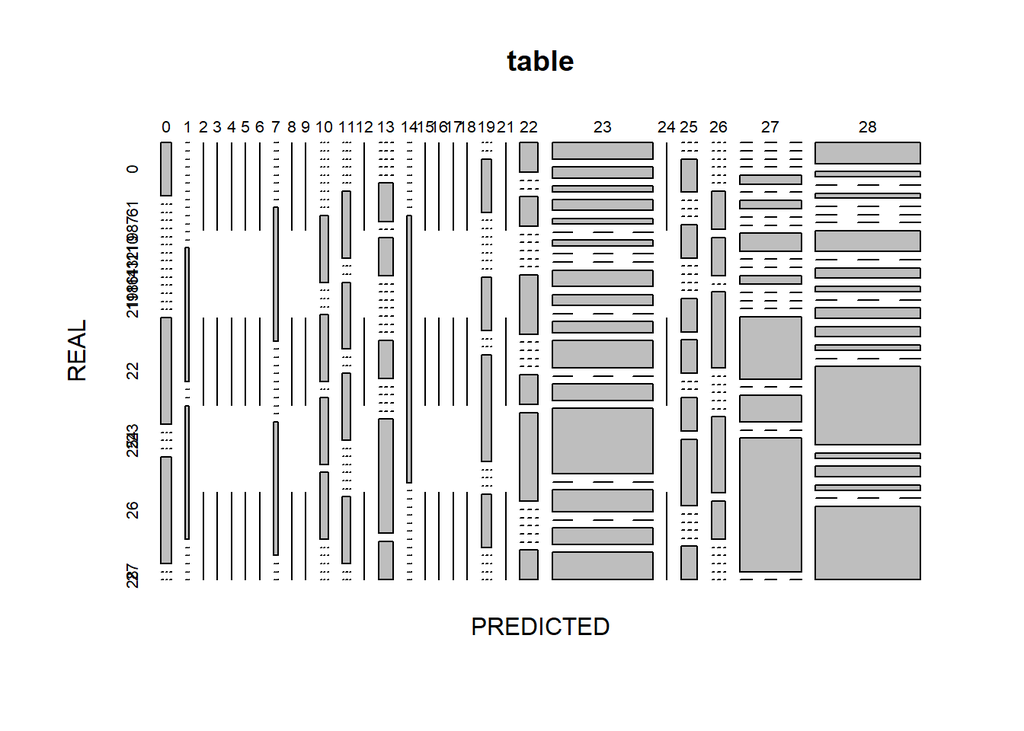

```r
mosaicplot(table)
```

### 2. С помощью дерева решений

```r
library(tree)
dt.train$Reason.for.absence = as.factor(dt.train$Reason.for.absence)
tree <- tree(Reason.for.absence ~ ., dt.train)

summary(tree)
```

```
##
## Classification tree:
## tree(formula = Reason.for.absence ~ ., data = dt.train)
## Variables actually used in tree construction:
##  [1] "Absenteeism.time.in.hours" "Month.of.absence"
##  [3] "Transportation.expense"    "Son"
##  [5] "Social.drinker"            "Weight"
##  [7] "Height"                    "Work.load.Average.day"
##  [9] "Pet"                       "Service.time"
## Number of terminal nodes:  16
## Residual mean deviance:  3.264 = 1759 / 539
## Misclassification error rate: 0.5279 = 293 / 555
```

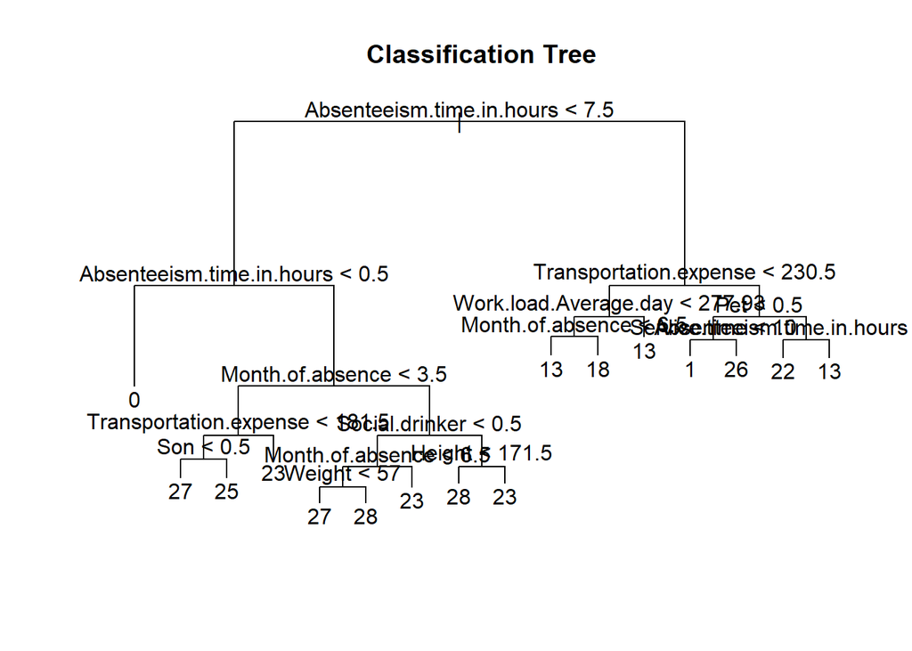

```r
plot(tree)
text(tree, pretty = 1)
title(main = "Classification Tree")
```

```r
predicted <- predict(tree, dt.test[,-indClass], type="class")
```

**Точность при использовании tree**

```r
sum(predicted == dt.test[, indClass])/nrow(dt.test)
```

```
## [1] 0.3945946
```

### 3. С помощью случайного леса

```r
library(randomForest)
reason.for.absence.rf = randomForest(Reason.for.absence ~ ., dt.train)
reason.for.absence.rf
```

```
##
## Call:
##  randomForest(formula = Reason.for.absence ~ ., data = dt.train)
##                Type of random forest: classification
##                      Number of trees: 500
## No. of variables tried at each split: 4
##
##         OOB estimate of  error rate: 54.05%
## Confusion matrix:
##     0 1 2 3 4 5 6 7 8 9 10 11 12 13 14 15 16 17 18 19 21 22 23 24 25 26 27 28
## 0  34 0 0 0 0 0 0 0 0 0  0  0  0  0  0  0  0  0  0  0  0  0  0  0  0  0  0  0
## 1   0 0 0 0 0 0 0 0 0 0  0  3  0  2  0  0  0  0  0  1  0  2  3  0  0  2  0  0
## 2   0 0 0 0 0 0 0 0 0 0  0  0  0  0  0  0  0  0  0  0  0  0  1  0  0  0  0  0
## 3   0 0 0 0 0 0 0 0 0 0  0  0  0  0  0  0  0  0  0  0  0  1  0  0  0  0  0  0
## 4   0 0 0 0 0 0 0 0 0 0  0  0  0  0  0  0  0  0  0  0  0  0  1  0  0  1  0  0
```

[output cut: 52 more lines]

**Оценим важность показателей**

```r
var.imp <- importance(reason.for.absence.rf)
var.imp
```

```
##                                 MeanDecreaseGini
## Month.of.absence                       46.593145
## Day.of.the.week                        33.735268
## Seasons                                21.743941
## Transportation.expense                 17.559930
## Distance.from.Residence.to.Work        17.654393
## Service.time                           14.476503
## Age                                    17.070132
## Work.load.Average.day                  45.881542
## Hit.target                             36.717197
## Disciplinary.failure                   15.455757
## Education                               5.635978
## Son                                    12.038139
## Social.drinker                          6.571522
## Social.smoker                           3.189929
## Pet                                     8.602822
## Weight                                 17.899965
## Height                                 14.297919
## Body.mass.index                        17.123591
## Absenteeism.time.in.hours              71.455587
```

```r
best.params <- var.imp[var.imp >35, ]
best.params
```

```
##          Month.of.absence     Work.load.Average.day                Hit.target
##                  46.59314                  45.88154                  36.71720
## Absenteeism.time.in.hours
##                  71.45559
```

**При использовании алгоритма “случайный лес” получили очень большую ошибку (порядка 50%), поэтому оценки важности показателей находятся на низком уровне**

**Точность при использовании randomForest**

```r
predicted <- predict(reason.for.absence.rf, dt.test[,-indClass], type="class")

sum(predicted == dt.test[, indClass])/nrow(dt.test)
```

```
## [1] 0.5027027
```

### 4. С помощью байесовской классификации

**Сменим показатель с причины отгула на сезон(время года), потому что классификация по причине прогула в данном методе не рассчитывается.**

```r
library(naivebayes)
# Сменим показатель, потому что классификация по причине прогула в данном методе не рассчитывается.
indClass <- 4 #1 - причина отгула, 4 - сезон

# получим заново тренировочный датасет, чтобы привести тип показателя к значениям по умолчанию.
dt.train <- dt[train.ind, ]
dt.train$Season = as.factor(dt.train$Season)

nb <- naivebayes::naive_bayes(Season ~., dt.train)


summary(nb)
```

```
##
## ================================== Naive Bayes ==================================
##
## - Call: naive_bayes.formula(formula = Season ~ ., data = dt.train)
## - Laplace: 0
## - Classes: 4
## - Samples: 555
## - Features: 20
## - Conditional distributions:
##     - Gaussian: 20
## - Prior probabilities:
##     - 1: 0.2252
##     - 2: 0.2577
##     - 3: 0.2523
##     - 4: 0.2649
##
## ---------------------------------------------------------------------------------
```

```r
predicted <- predict(nb, dt.test[,-indClass], type="class")
predicted
```

```
##   [1] 3 1 1 1 1 1 1 1 1 1 1 1 1 1 1 1 1 1 1 1 4 1 1 4 4 4 4 4 1 4 1 4 4 4 4 4 4
##  [38] 4 4 4 2 2 2 2 2 2 2 2 2 2 2 2 2 2 2 2 3 2 3 3 3 3 3 3 2 1 1 1 1 1 4 4 1 1
##  [75] 1 4 4 4 4 4 4 4 4 4 4 4 4 4 4 4 4 4 4 2 2 2 2 2 2 2 2 2 2 2 3 3 2 2 2 2 2
## [112] 2 3 3 2 2 1 2 1 1 3 1 1 1 1 1 1 1 4 1 4 4 4 4 4 4 4 4 2 2 2 2 2 2 2 2 2 3
## [149] 2 2 2 2 2 2 2 2 2 2 2 2 2 2 3 2 2 3 2 3 3 3 3 2 2 2 2 2 2 2 3 1 2 1 1 3 1
## Levels: 1 2 3 4
```

```r
table(PREDICTED = predicted, REAL = dt.test[, indClass])
```

```
##          REAL
## PREDICTED  1  2  3  4
##         1 36  0  2  8
##         2  3 46 23  0
##         3  3  1 18  0
##         4  3  2  0 40
```

**Точность при использовании naive_bayes**

```r
sum(predicted == dt.test[, indClass])/nrow(dt.test)
```

```
## [1] 0.7567568
```

### Задание 6. Выполним классификацию данных методом randomForest на подмножестве “важных” показателей из п.5

**1. подготовим датасет**

```r
# Сформируем набор выделенных признаков
selectedFeatures <- c("Reason.for.absence","Month.of.absence", "Work.load.Average.day", "Hit.target", "Absenteeism.time.in.hours")

# Выберем из тренировочного и тестового датасета выделенные признаки
dtWithSpecialFeature.train <- data.frame(dt.train[,selectedFeatures])
dtWithSpecialFeature.test <- data.frame(dt.test[,selectedFeatures])

# Сменим тип данных для задачи классификации
dtWithSpecialFeature.train$Reason.for.absence = as.factor(dtWithSpecialFeature.train$Reason.for.absence)

# установим целевой индетификатор класса (1 - причина отгула )
indClass <- 1

#классифицируем методов randomForest
reason.for.absence.rf = randomForest(Reason.for.absence ~ ., dtWithSpecialFeature.train)
```

**информация о классификации**

```r
reason.for.absence.rf
```

```
##
## Call:
##  randomForest(formula = Reason.for.absence ~ ., data = dtWithSpecialFeature.train)
##                Type of random forest: classification
##                      Number of trees: 500
## No. of variables tried at each split: 2
##
##         OOB estimate of  error rate: 63.6%
## Confusion matrix:
##     0 1 2 3 4 5 6 7 8 9 10 11 12 13 14 15 16 17 18 19 21 22 23 24 25 26 27 28
## 0  34 0 0 0 0 0 0 0 0 0  0  0  0  0  0  0  0  0  0  0  0  0  0  0  0  0  0  0
## 1   0 0 0 0 0 0 0 0 0 0  1  5  0  1  0  0  0  0  0  1  0  0  2  0  0  3  0  0
## 2   0 0 0 0 0 0 0 0 0 0  0  0  0  0  0  0  0  0  0  1  0  0  0  0  0  0  0  0
## 3   0 0 0 0 0 0 0 0 0 0  0  0  0  0  0  0  0  0  0  0  0  0  0  0  0  1  0  0
## 4   0 0 0 0 0 0 0 0 0 0  0  0  0  0  0  0  0  0  0  1  0  0  1  0  0  0  0  0
```

[output cut: 52 more lines]

**Точность классификации с учетом “важных” показателей**

```r
predicted <- predict(reason.for.absence.rf, dtWithSpecialFeature.test[,-indClass], type="class")

sum(predicted == dtWithSpecialFeature.test[, indClass])/nrow(dtWithSpecialFeature.test)
```

```
## [1] 0.3351351
```

## Вывод

В данной практической работе были изучены:

1. Основные компоненты языка R
2. Методы обработки данных перед их исследованием
3. Методы классификации данных с помощью базовых и сторонних пакетов языка R
4. Методы визуализации результатов обработки данных
5. Методы тестирования зависимостей показателей между собой
6. Методы оценки важности показателей